# Coursework Report

*N* removed NAs: 3

*N* removed typo: 1

*N* removed <18: 18

*N* total clean: 128

| Group | *N* | *M*<sub>age</sub> | *M*<sub>rating</sub> |
| --- | --- | --- | --- |
| Control | 61 | 21.18 | 5.37 |
| Experim | 67 | 20.90 | 6.31 |

**Main analysis results**

*t*(126) = -6.92, *p* < .001

[interactive chart not shown]

[figure not shown]

[interactive chart not shown]

# Coursework Report

Analysing Data, Spring 2020

# Methods

## Participants

Table 1: Descriptive statistics by experimental condition

| Group | Number of participants | Mean age | SD age | Min age | Max age |
| --- | --- | --- | --- | --- | --- |
| White | 61 | 21.18 | 2.01 | 18 | 25 |
| Red | 67 | 20.90 | 2.02 | 18 | 26 |

## Design

The conceptual hypothesis of this replication stands as ‘participants who see the picture of a man on a red background will find the man more attractive than those participants who see the picture of a man on a white background’. The picture would be 8" by 10" (8x10).  
To measure attractiveness levels, ratings scores on a 9 point scale will be used in the analysis. A high score of 8/9 would mean the participant finds the person extremely attractive, and a low score of 1 means they do not find the person attractive. The attractiveness ratings would be given in accordance with the following questions: “How attractive did you find the person you just saw?”, “how pleasant was the person to look at”? and “if i were to meet this person in real life, I would think he is attractive”.  
Composite scores were calculated from the scores of each participant on 3 opinion scales for each three questions. These 3 questions assessed the main question of whether women found the man in a red background attractive. A new variable was created from the average mean scores from the ratings and placed at the end of the data as an extra column.  
The operational hypothesis stands as ‘there will be higher mean attractiveness scores for those in the red condition than those in the white condition’.  
An independent sample t test will be used to examine the significance of the effect of the colour red on perceived attractiveness levels. This test will assess the different mean scores elicited by the 2 different conditions, to determine whether this red effect assumption can be applied to the population.

# Results

Table 2: Mean scores of ratings for each group

| Group | Number of participants | Mean score | SD | Min range | Max range |
| --- | --- | --- | --- | --- | --- |
| White | 61 | 5.37 | 0.76 | 3.67 | 7.67 |
| Red | 67 | 6.31 | 0.78 | 4.00 | 8.00 |

To evaluate whether there was a sufficiently big difference to believe that the 2 sample means from each conditions do not come from the same population, the standard deviation of the differences in the means was generated to produce the test statistic t. The t value is a negative value, *t* (126) = -6.92 which explains the difference between the sample means is almost 7 times bigger than the standard error of difference.  
As the p value is very small (*p* = 0 ), it is unlikely that these sample means come from the same population. The p value is less than 0.05 probability, and therefore the null hypothesis is rejected, and the alternative hypothesis is accepted, in this case with 95% confidence. This means that the colour red significantly affected the ratings of attractiveness than the white condition. The confidence interval supports this as both bounds of the confidence intervals are below 0. This suggests that for 95% certainty the range of values contains the population mean. In addition to that, the lower and higher confidence intervals of 95% CI [-1.22, -0.68] are both negative. As both intervals are negative and the intervals do not contain 0, there is significance at the 0.05 level.  
In short, the result of the analysis suggests that when a participant was in the red group condition, attractiveness ratings were higher than those in the white condition. So, red had an effect on attractiveness ratings.  
Here is a figure of the data showing the mean score ratings of attractiveness for each group condition.

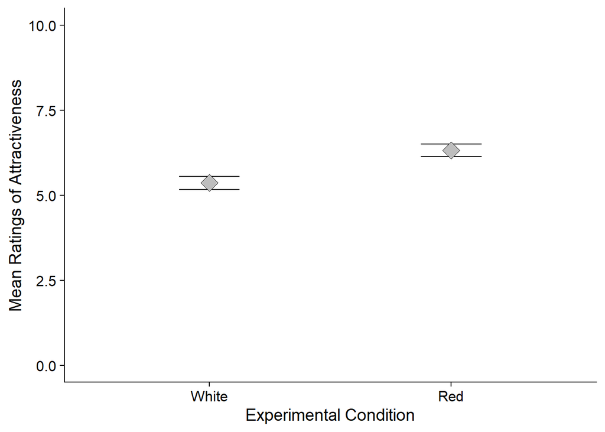

## Discussion

The overall pattern of results confirms the original hypothesis that red would influence participants ratings. This suggests that colour affects the way people perceive others and this can be unconsciously done. Red signals attraction and has positive connotations, which influence a woman’s perceptions and desires of men. This ‘red effect’ means that colour unconsciously affects processes of experiencing attraction, since red highlights someone more.  
In comparison to the original study of experiment 1 by Elliot et al., (2010), this current experiment had similar results in revealing that red affects ratings of attractiveness. The man was more attractive on a red background. Both the p values of this current experiment and the original study’s experiment was less than 0.05, suggesting red’s significant and genuine effect on perceived attractiveness.  
One strength of the current experiment was from the volunteer sample of participants where participants willingly chose to take part in the study. This attracted a range of different females in the study, not targeted at one specific race etc. This is a strength because the results aren’t specific to one type of person. However, one could argue that the results aren’t valid as the results are specific to females in age ranges of 18-26, because only female participants were used. Therefore, the results are not generalisable to other ages and genders.  
However, plenty experiments support the current experiment’s results in various contexts. For example, waitresses were more likely to get higher tips dressed in red, than in other colours (Gueguen & Jacob, 2014). This suggests that the red effect extends beyond the laboratory- based setting and applies to the real world. Also, Guguen & Jacob (2013) found women in red were offered more free rides with passing vehicles (Gueguen, 2010), highlighting the attention red brings. Therefore, this red effect is real in extending beyond the laboratory setting and applying to various contexts.  
Elliot and Maier’s (2013) study’s results contrast the current experiments results. The current experiment’s results showed the colour red’s significance, whereas Elliot and Maier’s (2013) study showed results with a weak direction and no statistical significance. They suggested the size of the effect might be too small and only a bigger sample could identify a statistical difference, if it even exists. This means that the red effect might be non-existent or even a fluke.  
In some aspect, the red effect might still be real, as much research in this field has generated similar results to the current experiment, highlighting the significance of the colour red. Elliot and Niesta (2008) investigated the red romance hypothesis and found that women rated men in red shirts as more attractive, as they associated the colour red with a romantic man. This highlights the positive associations of the colour red.  
However, there is a concern over the alleged publication bias in the results of this study. Critiques have argued that the null results are often unpublished in psychology (Ferguson & Brannick 2012). Therefore, some say these results may have had contradictory evidence to the hypothesis and that the results were fabricated to support the alternative hypothesis, as this is common in psychology. In fact, research has found that many studies report the supportive results of the hypothesis in journals, and 95.6% to 97.3% provide support for the primary hypothesis (Sterling, 1959; Sterling, Rosenbaum & Weinkam, 1995). Subsequently, this suggests that the red effect might not be real as research in psychology may be supportive of a red effect bias, when actually there exists no effect. The red effect might not be real but fabricated.  
Contrastingly, studies have shown this red effect might actually be real because it exists in animals too. The red colour in the alpha male mandrill notions dominance and status. Their genitals increase as their ranking increases, demonstrating a symbol of male dominance and status in animals- something female mandrills are attracted to. This gives them a primitive advantage to mate and increase in their species (Setchel and Dixson, 2001). Furthermore, stickleback female fish demonstrate a prominent red effect influencing attraction. They are attracted to the red colour in males. This is because they associate the colour red with power, when males defend their territories. This then exhibits a powerful status to a female which increases attraction (Milinski and Bakker, 1990). Both these studies effectively demonstrate the existing real red effect in humans and animals.  
This research question is worth investigating further due to the mixed results from various psychologists in this field, regarding red’s significance. Extensive research should be done to clarify an association between attraction and the colour red.

Types of clothing should be investigated to see if they affect attraction. For example, certain shirt colours should be worn to see the impact on attraction levels. Research should investigate attractiveness levels of a man or woman in red on dating websites, to see whether they really find the opposite gender more attractive with this colour (Sullivan et al., 2017). Experiments should utilise dating websites, and images of people in red to see the red effect in action.  
Further research should focus on what colours to avoid wearing on dates to prevent the loss of attraction. Experiments could test certain colours on a first date to see the impression they give off. This would allow men and women to prepare thoroughly before going on a first date. Certain colours carry a sex appeal, and the colour red attracts men more to women and encourages sexual behaviour(Clark, 2017, cited in Sullivan et al., 2017). So, if red determines sexual behaviour, then more research should focus on what appeal other colours give to see the effects they have on the mind subconsciously. This then allows people to choose what appeal to give through the colour of their clothes.  
Additionally, women found men with the colour red around their chest area more attractive than shades of other colours like black or white. So, more research should be done to see on what part of the body, colours should be worn to determine attraction (Sullivan et al., 2017). For example, men could wear certain types of shirts colours on different parts of the body focusing on red around the chest, to see if this effect is significant and genuine.  
To conclude, the results of this experiment suggest how colour carries meaning and impacts one’s dating life and their perceptions of men. Colour acts as a key determinant in influencing levels of attraction. There exists some relationship between the colour red and levels of attractiveness as the results have shown a significant effect. Various research has supported and extended this red effect into real life and not just in the laboratory setting. However, while there is an existing relationship between the colour red and attraction levels, it is still one of many significant factors which affects attraction.

# References

Elliot, A., Niesta Kayser, D., Greitemeyer, T., Lichtenfeld, S., Gramzow, R., Maier, M., & Liu, H. (2010). Red, Rank, and Romance in Women Viewing Men. Journal of Experimental Psychology: General, 139(3), 399-417. doi: 10.1037/a0019689

Elliot, A., & Maier, M. (2013). The red-attractiveness effect, applying the Ioannidis and Trikalinos (2007b) test, and the broader scientific context: A reply to Francis (2013). Journal Of Experimental Psychology: General, 142(1), 297-300. https://doi.org/10.1037/a0029592

& Brannick, M. (2012). Publication bias in psychological science: Prevalence, methods for identifying and controlling, and implications for the use of meta-analyses. Psychological Methods, 17(1), 120-128. https://doi.org/10.1037/a0024445

Guéguen, N. (2010). Color and women hitchhikers’ attractiveness: Gentlemen drivers prefer red. Color Research & Application, 37(1), 76-78. https://doi.org/10.1002/col.20651

Guéguen, N., & Jacob, C. (2012). Color and cyber-attractiveness: Red enhances men’s attraction to women’s internet personal ads. Color Research & Application, 38(4), 309-312. https://doi.org/10.1002/col.21718

Gueguen, N., & Jacob, C. (2014). Clothing color and tipping: Gentlemen patrons give more tips to waitresses with red clothes. Journal of Hospitality & Tourism Research, 38, 275–280. doi:10.1177/ 1096348012442546

Hill, E., Nocks, E., & Gardner, L. (1987). Physical attractiveness: Manipulation by physique and status displays. Ethology And Sociobiology, 8(2), 143-154. https://doi.org/10.1016/0162-3095(87)90037-9

Milinski, M., & Bakker, T. (1990). Female Sticklebacks use Male Coloration in Mate Choice  
and Hence Avoid Parasitized Males. Nature, 344(6264), 330-333. doi: 10.1038/344330a0

Sterling, T. (1959). Publication Decisions and Their Possible Effects on Inferences Drawn from Tests of Significance–Or Vice Versa. Journal Of The American Statistical Association, 54(285), 30. https://doi.org/10.2307/2282137

Sterling, T., Rosenbaum, W., & Weinkam, J. (1995). Publication Decisions Revisited: The Effect of the Outcome of Statistical Tests on the Decision to Publish and Vice Versa. The American Statistician, 49(1), 108-112. https://doi.org/10.1080/00031305.1995.10476125

Sullivan, CR., Kazlauciunas, A., & Guthrie JT. (2017). Colored Apparel - Relevance to Attraction in Humans. Journal Of Fashion Technology & Textile Engineering, 05(03). https://doi.org/10.4172/2329-9568.1000157